# Question

La gráfica y la tabla muestran parte de la información que recibe la familia López en su factura telefónica del mes de enero.

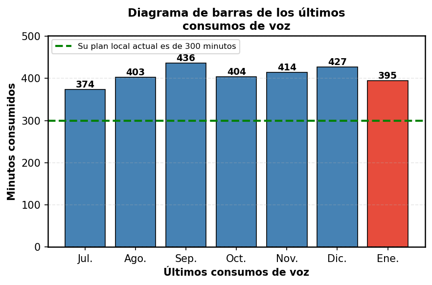

[figure not shown]

El tiempo adicional consumido por la familia López en enero fue:

## Answerlist

- 2 horas y 25 minutos.
- 1 hora y 8 minutos.
- 5 horas y 41 minutos.
- 1 hora y 35 minutos.

# Solution

Para resolver este problema, debemos:

1. **Identificar el plan actual**: Según la gráfica, el plan local actual es de **300 minutos**.
2. **Identificar el consumo de enero**: En el gráfico de barras, el consumo de enero (la última barra) es de **395 minutos**.
3. **Calcular el tiempo adicional**:
   $$\text{Tiempo adicional} = \text{Consumo enero} -
   \text{Plan actual}$$
   $$\text{Tiempo
   adicional} = 395 - 300 = 95 \text{ minutos}$$
4. **Convertir a horas y minutos**:
   - Horas: $\lfloor 95 \div 60 \rfloor = 1$ hora(s)
   - Minutos restantes: $95 \mod 60 = 35$ minutos

**Respuesta correcta**: 1 hora y 35 minutos.

## Answerlist

- Falso
- Falso
- Falso
- Verdadero

# Meta-information

exname: consumo_telefonico_adicional extype: schoice exsolution: 0001 exshuffle: TRUE exsection: Estadística/Interpretación de Gráficos/Nivel 2 extags: ICFES, Interpretación, Numérico-Variacional, Estadística, Aplicado exdificultad: 2 excompetencia: Interpretación y Representación excomponente: Numérico-Variacional expensamiento: Pensamiento Numérico excontenido: Estadística (Genérico) exeje: Aplicado/Contextualizado